# Capital One Challenge: Analysis On NYC Green Taxis

Zeen Liu

07/29/2017

## 1.Business Understanding

New York Ciity is the most populous city in the United States, located at the southern tip od the state of New York. The taxis of New York City are widely recognized icons of the city and come in two varieties: yellow and green.Our project is focused on the green taxis in New York City area. The green taxis(street hail vehicles,commonly konwn as “boro taxis”), which began to appear in August 2013, are allowed to pick up passengers in Upper Manhattan, the Bronx, Brooklyn, Queens, and Staten Island.

## 2.Question Of Interest

### Question 1

> - *Programmatically download and load into analytical tool the trip data for September 2015.*

```r
#Using fread in data.table for importing data from csv directly into R.
if(!require('data.table')){install.packages('data.table'); require('data.table')}
if(!require('curl')){install.packages('curl'); require('curl')}
green_taxi<-fread("https://s3.amazonaws.com/nyc-tlc/trip+data/green_tripdata_2015-09.csv")
```

[output not shown]

> - *Report how many rows and columns of data you have loaded.*

```r
cat('The NYC Green Taxi data set in september 2015 includes', nrow(green_taxi), 'observations and', ncol(green_taxi), 'variables.')
```

```
## The NYC Green Taxi data set in september 2015 includes 1494926 observations and 21 variables.
```

```r
#check the summary table to get a basic understanding of data.
summary(green_taxi)
```

```
##     VendorID     lpep_pickup_datetime Lpep_dropoff_datetime
##  Min.   :1.000   Length:1494926       Length:1494926
##  1st Qu.:2.000   Class :character     Class :character
##  Median :2.000   Mode  :character     Mode  :character
##  Mean   :1.782
##  3rd Qu.:2.000
##  Max.   :2.000
##
##  Store_and_fwd_flag   RateCodeID     Pickup_longitude Pickup_latitude
##  Length:1494926     Min.   : 1.000   Min.   :-83.32   Min.   : 0.00
##  Class :character   1st Qu.: 1.000   1st Qu.:-73.96   1st Qu.:40.70
##  Mode  :character   Median : 1.000   Median :-73.95   Median :40.75
##                     Mean   : 1.098   Mean   :-73.83   Mean   :40.69
##                     3rd Qu.: 1.000   3rd Qu.:-73.92   3rd Qu.:40.80
##                     Max.   :99.000   Max.   :  0.00   Max.   :43.18
##
##  Dropoff_longitude Dropoff_latitude Passenger_count Trip_distance
##  Min.   :-83.43    Min.   : 0.00    Min.   :0.000   Min.   :  0.000
##  1st Qu.:-73.97    1st Qu.:40.70    1st Qu.:1.000   1st Qu.:  1.100
##  Median :-73.95    Median :40.75    Median :1.000   Median :  1.980
##  Mean   :-73.84    Mean   :40.69    Mean   :1.371   Mean   :  2.968
##  3rd Qu.:-73.91    3rd Qu.:40.79    3rd Qu.:1.000   3rd Qu.:  3.740
##  Max.   :  0.00    Max.   :42.80    Max.   :9.000   Max.   :603.100
##
##   Fare_amount          Extra            MTA_tax          Tip_amount
##  Min.   :-475.00   Min.   :-1.0000   Min.   :-0.5000   Min.   :-50.000
##  1st Qu.:   6.50   1st Qu.: 0.0000   1st Qu.: 0.5000   1st Qu.:  0.000
##  Median :   9.50   Median : 0.5000   Median : 0.5000   Median :  0.000
##  Mean   :  12.54   Mean   : 0.3513   Mean   : 0.4866   Mean   :  1.236
##  3rd Qu.:  15.50   3rd Qu.: 0.5000   3rd Qu.: 0.5000   3rd Qu.:  2.000
##  Max.   : 580.50   Max.   :12.0000   Max.   : 0.5000   Max.   :300.000
##
##   Tolls_amount      Ehail_fee      improvement_surcharge  Total_amount
##  Min.   :-15.2900   Mode:logical   Min.   :-0.3000       Min.   :-475.00
##  1st Qu.:  0.0000   NA's:1494926   1st Qu.: 0.3000       1st Qu.:   8.16
##  Median :  0.0000                  Median : 0.3000       Median :  11.76
##  Mean   :  0.1231                  Mean   : 0.2921       Mean   :  15.03
##  3rd Qu.:  0.0000                  3rd Qu.: 0.3000       3rd Qu.:  18.30
##  Max.   : 95.7500                  Max.   : 0.3000       Max.   : 581.30
##
##   Payment_type     Trip_type
##  Min.   :1.000   Min.   :1.000
##  1st Qu.:1.000   1st Qu.:1.000
##  Median :2.000   Median :1.000
##  Mean   :1.541   Mean   :1.022
##  3rd Qu.:2.000   3rd Qu.:1.000
##  Max.   :5.000   Max.   :2.000
##                  NA's   :4
```

### Data cleaning and manipulation

First we creat time variables **week_day** and **num_week** for further use.

Before moving to analysis part, the data should be cleaned and manipulated first. From the summary table, some missing values are found in the data, some values are recorded inappropriately, such as there are some negative values in Fare_amount.

There are two simple ways to handle this, one is just deleting the observations with missing values, the other way is to fill the NA with mean(numeric variables or mode(categorical variables).

First looking at **Trip_type**, there are only 4 observations with missing value, and we have over 1000000 observations, so it is safe to delete observations with missing value since the number of observations is large enough, and the number of missing value is only a small fraction of it.

```r
#creat time variables
if(!require('lubridate')){install.packages('lubridate'); require('lubridate')}
green_taxi <- as.data.frame(green_taxi)
pick_time<- strptime(green_taxi$lpep_pickup_datetime,"%Y-%m-%d %H:%M:%S")
week_day <- weekdays(as.Date(pick_time))
green_taxi$week_day <- as.factor(week_day)
green_taxi$num_week <- as.factor(week(pick_time)-34)

##Delete the observations with missing values in Trip_type
green_clean<- green_taxi[is.na(green_taxi[ , 21]) == 0, ]
```

From the summary, some negative values or o appear in **Tip_amount, Tolls_amount, Fare_amount, Total_amount and etc**. Based on the data dictionary and common knowledge, the observations with inappropriate values will be deleted. Besides, the **RateCodeID** is a categorical variable from 1 to 6 according to the data dictionatry. Therefore, the max value of 99 does not make sense. 0 in lattitude and longitude should also be deleted.

```r
#Delete observations with negative values in Extra, MTA_tax, Tip_amount, Tolls_amount, improvement_surcharge

for (i in c(13:16,18))
  green_clean <- green_clean[green_clean[,i] >= 0, ]

#Delete observations with negative values or o in Trip_distance, Fare_amount, Total_amount
for (i in c(10:12,19))
  green_clean <- green_clean[green_clean[,i] > 0, ]

#Delete the observations with error in RateCodeId
green_clean <- green_clean[green_clean$RateCodeID <= 6,]

#Delete observations with zero in the lattitude/longitude.
for (i in c(6:9))
  green_clean <- green_clean[green_clean[,i] != 0, ]

#Using as.factor function to ensure that categorical variables treated correctedly
green_clean$RateCodeID <- as.factor(green_clean$RateCodeID)
green_clean$Payment_type <- as.factor(green_clean$Payment_type)
green_clean$Trip_type <- as.factor(green_clean$Trip_type)

summary(green_clean)
```

```
##     VendorID     lpep_pickup_datetime Lpep_dropoff_datetime
##  Min.   :1.000   Length:1466903       Length:1466903
##  1st Qu.:2.000   Class :character     Class :character
##  Median :2.000   Mode  :character     Mode  :character
##  Mean   :1.784
##  3rd Qu.:2.000
##  Max.   :2.000
##
##  Store_and_fwd_flag RateCodeID  Pickup_longitude Pickup_latitude
##  Length:1466903     1:1439136   Min.   :-75.37   Min.   :39.36
##  Class :character   2:   3396   1st Qu.:-73.96   1st Qu.:40.70
##  Mode  :character   3:    860   Median :-73.95   Median :40.75
##                     4:    909   Mean   :-73.94   Mean   :40.75
##                     5:  22580   3rd Qu.:-73.92   3rd Qu.:40.80
##                     6:     22   Max.   :-71.08   Max.   :43.18
##
##  Dropoff_longitude Dropoff_latitude Passenger_count Trip_distance
##  Min.   :-76.12    Min.   :39.43    Min.   :1.000   Min.   :  0.010
##  1st Qu.:-73.97    1st Qu.:40.70    1st Qu.:1.000   1st Qu.:  1.110
##  Median :-73.95    Median :40.75    Median :1.000   Median :  2.000
##  Mean   :-73.93    Mean   :40.75    Mean   :1.372   Mean   :  3.011
##  3rd Qu.:-73.91    3rd Qu.:40.79    3rd Qu.:1.000   3rd Qu.:  3.790
##  Max.   :-72.21    Max.   :42.80    Max.   :9.000   Max.   :603.100
##
##   Fare_amount         Extra           MTA_tax        Tip_amount
##  Min.   :  0.01   Min.   :0.0000   Min.   :0.000   Min.   :  0.000
##  1st Qu.:  6.50   1st Qu.:0.0000   1st Qu.:0.500   1st Qu.:  0.000
##  Median :  9.50   Median :0.5000   Median :0.500   Median :  0.000
##  Mean   : 12.59   Mean   :0.3556   Mean   :0.492   Mean   :  1.234
##  3rd Qu.: 15.50   3rd Qu.:0.5000   3rd Qu.:0.500   3rd Qu.:  2.000
##  Max.   :580.50   Max.   :1.0000   Max.   :0.500   Max.   :300.000
##
##   Tolls_amount     Ehail_fee      improvement_surcharge  Total_amount
##  Min.   : 0.0000   Mode:logical   Min.   :0.0000        Min.   :  0.01
##  1st Qu.: 0.0000   NA's:1466903   1st Qu.:0.3000        1st Qu.:  8.30
##  Median : 0.0000                  Median :0.3000        Median : 11.76
##  Mean   : 0.1241                  Mean   :0.2953        Mean   : 15.09
##  3rd Qu.: 0.0000                  3rd Qu.:0.3000        3rd Qu.: 18.30
##  Max.   :95.7500                  Max.   :0.3000        Max.   :581.30
##
##  Payment_type Trip_type        week_day      num_week
##  1:691489     1:1444552   Friday   :218298   1: 83193
##  2:768804     2:  22351   Monday   :162050   2:339666
##  3:  3315                 Saturday :255507   3:352776
##  4:  3236                 Sunday   :216916   4:350637
##  5:    59                 Thursday :187859   5:340631
##                           Tuesday  :205849
##                           Wednesday:220424
```

Seeing form the summary table, some exteme values can be found such as 300 in **Tip_amount**, they are not deleted in this step, but those observations with exteme values should be treated carefully in the following analysis.

```r
#print result
cat("Total observations in raw data is",nrow(green_taxi),", total observations in cleaned data is",nrow(green_clean),",deleting",nrow(green_taxi)-nrow(green_clean),"observations.", "The cleaned data set is", round(nrow(green_clean)/nrow(green_taxi)*100,2),"% of the original data.")
```

```
## Total observations in raw data is 1494926 , total observations in cleaned data is 1466903 ,deleting 28023 observations. The cleaned data set is 98.13 % of the original data.
```

### Question 2

> - *Plot a histogram of the number of the trip distance (“Trip Distance”).* Here a histogram of Trip Distance is plotted. Since most of the trip distance is less than 15 miles, so the X axis is limited between 0 and 15.

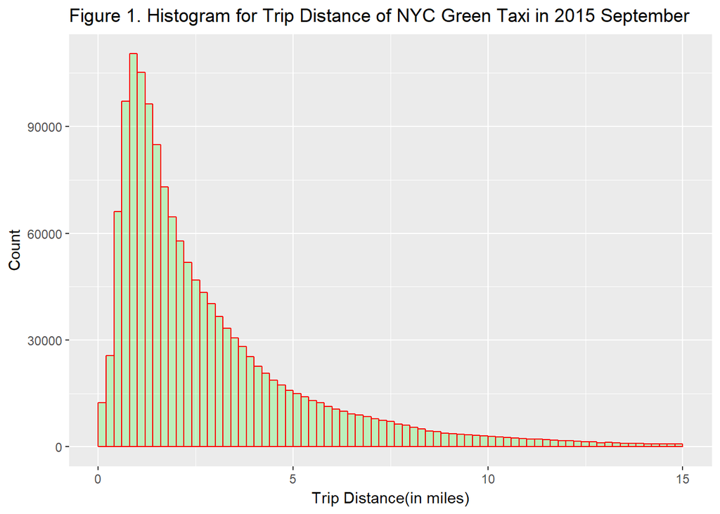

```r
#loading package
if(!require('ggplot2')){install.packages('ggplot2'); require('ggplot2')}
#Using ggplot to plot histogram
ggplot(data=green_clean, aes(green_clean$Trip_distance)) +
  geom_histogram(breaks=seq(0, 15, by = 0.2), col="red", fill="green", alpha = .2) +
  labs(title="Figure 1. Histogram for Trip Distance of NYC Green Taxi in 2015 September") +
  labs(x="Trip Distance(in miles)", y="Count") +
  xlim(c(0,15))
```

```r
cat("There are about", round(sum(green_clean$Trip_distance < 10)/nrow(green_clean)*100, 2), "% trips are less than 10 miles.", '\n')
```

```
## There are about 96.33 % trips are less than 10 miles.
```

> - *Report any structure you find and any hypotheses you have about that structure.*

**This distribution has a structure of log normal disttribution.**

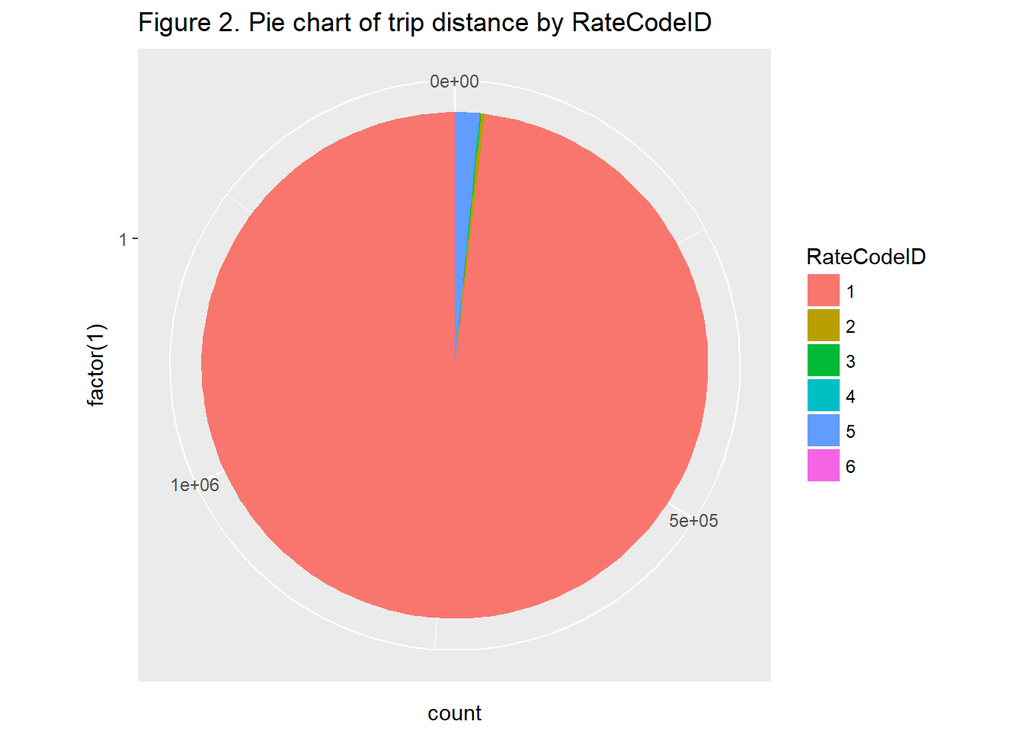

```r
#plot pie chart
ggplot(green_clean, aes(x = factor(1), fill = RateCodeID)) + geom_bar(width = 1) + coord_polar(theta = "y") + ggtitle("Figure 2. Pie chart of trip distance by RateCodeID")
```

To explore further, the pie plot shows the most of observations is belonged to **RateCodeID=1**, which indicate most of trips use standard rate. **RateCodeID=5** comes leads second.

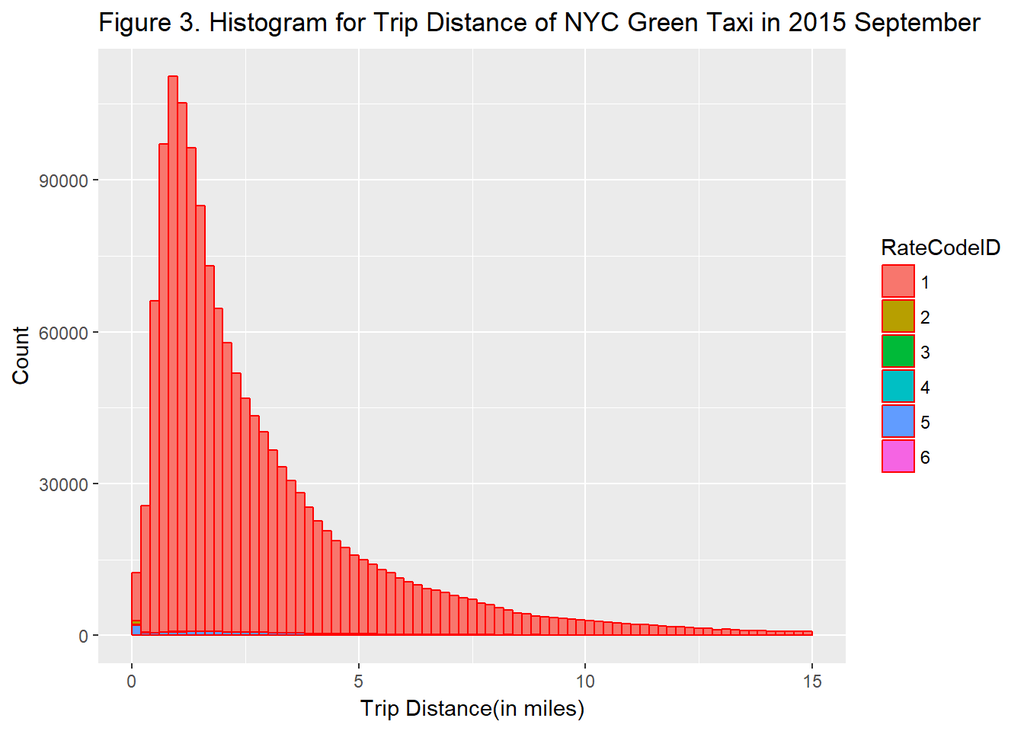

```r
ggplot(green_clean, aes(Trip_distance, fill = RateCodeID)) + geom_histogram(breaks=seq(0, 15, by = 0.2), col="red") +
  labs(title="Figure 3. Histogram for Trip Distance of NYC Green Taxi in 2015 September") +
  labs(x="Trip Distance(in miles)", y="Count") +
  xlim(c(0,15))
```

From Figure 3, We can see that the right skewness of the distribution of trip distance when RatecodeID is one contributes to the right skewness of distribution of trip distance.

### Question 3

> - *Report mean and median trip distance grouped by hour of day.*

```r
#Using strptime function to get pick up day hour
Day_hour <- strptime(green_clean$lpep_pickup_datetime,"%Y-%m-%d %H:%M:%S")[[3]]
#Calculate the man and median by tapply function
green_clean$Day_hour<- as.factor(Day_hour)
Distance_mean<- tapply(green_clean$Trip_distance, green_clean$Day_hour, mean)
Distance_median<- tapply(green_clean$Trip_distance, green_clean$Day_hour, median)
dis_hour <- rbind(Distance_mean, Distance_median)
dis_hour
```

```
##                        0        1        2       3        4        5
## Distance_mean   3.153617 3.057284 3.094847 3.26147 3.588001 4.214394
## Distance_median 2.240000 2.170000 2.200000 2.26000 2.400000 2.990000
##                        6        7       8        9       10       11
## Distance_mean   4.137097 3.332923 3.08626 3.045149 2.991853 2.961994
## Distance_median 2.900000 2.200000 2.00000 2.000000 1.970000 1.900000
##                       12     13      14       15       16       17
## Distance_mean   2.953102 2.9305 2.91534 2.907654 2.824599 2.715611
## Distance_median 1.910000 1.9000 1.87000 1.860000 1.830000 1.800000
##                       18      19       20       21       22      23
## Distance_mean   2.688529 2.74732 2.811718 3.034656 3.223879 3.23053
## Distance_median 1.810000 1.88000 1.930000 2.070000 2.220000 2.26000
```

> - *We’d like to get a rough sense of identifying trips that originate or terminate at one of the NYC area airports. Can you provide a count of how many transactions fit this criteria, the average fair, and any other interesting characteristics of these trips.*

**Missing counts in the airport:**

Checking form the website. URL:http://www.nyc.gov/html/tlc/html/about/trip_record_data.shtml “All trips between JFK International Airport and New York City destinations other than Manhattan will use that standard metered rate.”

The trips originates or terminates at JFK airport recorded as **RateCodeID=2**,the trips originates or terminates at Newark airport recorded **RateCodeID=3**, but the trips form/to LGA and the trips from/to New York City destinations other than Manhattan should be conuted. Google map helps to find those observations, the trips start or end in the circle which are drawn in the map are identified as airport trips. First find the center of the airport by latitude and longitude, then calculating the distance from the center. If distance is greater than radius, recorded as “not airport”, else recorded as airport trip.

[figure not shown]

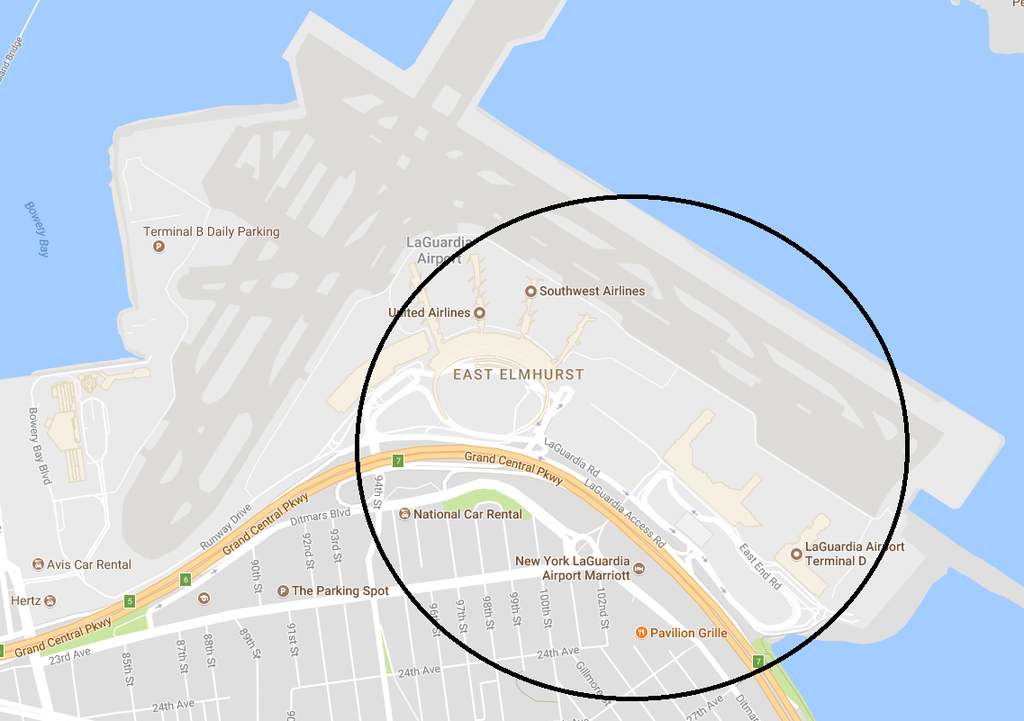

```r
#build new variable "Airport" to record the airport trip which gained from RatecodeID
air_taxi<-green_clean
air_taxi$Airport<-"Not airport"
air_taxi$Airport[air_taxi$RateCodeID == 2]<- "JFK"
air_taxi$Airport[air_taxi$RateCodeID == 3]<- "NWK"
#calculate the distance from the center of the LGA airport
LGA_loc <- c(40.7724,-73.8668)
air_taxi$LGA_dist_pick <- sqrt((air_taxi$Pickup_latitude - LGA_loc[1])^2 + (air_taxi$Pickup_longitude - LGA_loc[2])^2)
air_taxi$LGA_dist_drop <- sqrt((air_taxi$Dropoff_latitude - LGA_loc[1])^2 + (air_taxi$Dropoff_longitude - LGA_loc[2])^2)
#calculate the distance from the center of the JFK airport
JFK_loc <- c(40.64415,-73.7872)
air_taxi$JFK_dist_pick <- sqrt((air_taxi$Pickup_latitude - JFK_loc[1])^2 + (air_taxi$Pickup_longitude - JFK_loc[2])^2)
air_taxi$JFK_dist_drop <- sqrt((air_taxi$Dropoff_latitude - JFK_loc[1])^2 + (air_taxi$Dropoff_longitude - JFK_loc[2])^2)
#distance smaller than radius set to each airport, store index vector
index_LGA<- ((air_taxi$LGA_dist_pick<0.0054 & air_taxi$JFK_dist_drop>= 0.065 )| (air_taxi$LGA_dist_drop<0.0054 & air_taxi$JFK_dist_pick>= 0.065)) & air_taxi$Airport=="Not airport"
index_JFK<- ((air_taxi$JFK_dist_pick<0.065 & air_taxi$LGA_dist_drop>=0.0054) | (air_taxi$JFK_dist_drop<0.065 & air_taxi$LGA_dist_pick>=0.0054)) & air_taxi$Airport=="Not airport"
index_LGA_JFK <- ((air_taxi$JFK_dist_pick<0.065 & air_taxi$LGA_dist_drop<0.0054) | (air_taxi$JFK_dist_drop<0.065 & air_taxi$LGA_dist_pick<0.0054)) & air_taxi$Airport=="Not airport"
#set values to Airport
air_taxi$Airport[index_LGA]<- "LGA"
air_taxi$Airport[index_JFK]<- "JFK"
air_taxi$Airport[index_LGA_JFK]<- "JFK-LGA/LGA-JFK"
air_taxi<- air_taxi[,-c(26:29)]
#make them categorical
air_taxi$Day_hour <- as.factor(air_taxi$Day_hour)
air_taxi$Airport <- as.factor(air_taxi$Airport)
#print result
cat("There are roughly about", nrow(air_taxi[air_taxi$Airport!="Not airport",]), "airport trips ", "in September 2015")
```

```
## There are roughly about 53158 airport trips  in September 2015
```

```r
cat("Average fare (calculated by the meter) of trips to/from NYC airports:", round(mean(air_taxi$Fare_amount[air_taxi$Airport!="Not airport"]),2), "dollar.")
```

```
## Average fare (calculated by the meter) of trips to/from NYC airports: 25.68 dollar.
```

```r
cat("Average total charged amount (before tip) of trips to/from NYC airports:", round(mean(air_taxi$Total_amount[air_taxi$Airport!="Not airport"]),2), "dollar.")
```

```
## Average total charged amount (before tip) of trips to/from NYC airports: 30.11 dollar.
```

Figure 4 shows that most of the airport trips are gorm/to JFK, about 75%, from/to LGA comes second, around 20%. It shows John F. Kennedy Airport is the biggest airport in New York City area, so most of the airport trips are from/to JFK. It also shows that transfer airport trips between JFK and LGA.

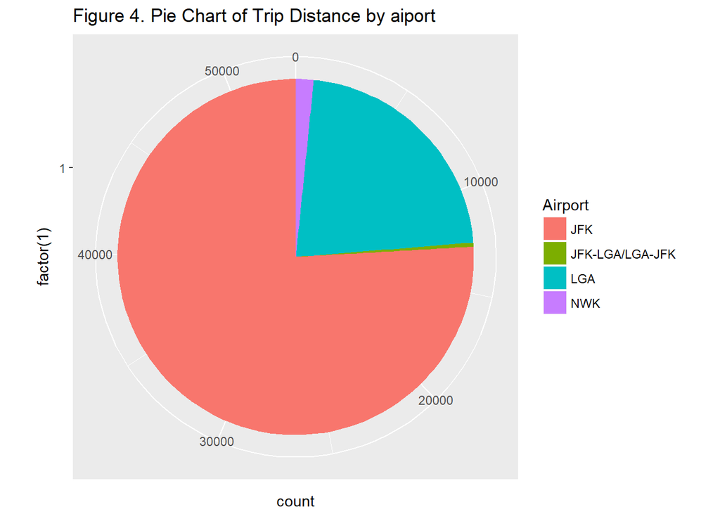

```r
#pie chart plot
ggplot(air_taxi[air_taxi$Airport!="Not airport",], aes(x = factor(1), fill = Airport)) + geom_bar(width = 1) + coord_polar(theta = "y") + ggtitle("Figure 4. Pie Chart of Trip Distance by aiport")
```

```r
#multiplot function
multiplot <- function(..., plotlist=NULL, file, cols=1, layout=NULL) {
  library(grid)

  # Make a list from the ... arguments and plotlist
  plots <- c(list(...), plotlist)

  numPlots = length(plots)

  # If layout is NULL, then use 'cols' to determine layout
  if (is.null(layout)) {
    # Make the panel
    # ncol: Number of columns of plots
    # nrow: Number of rows needed, calculated from # of cols
    layout <- matrix(seq(1, cols * ceiling(numPlots/cols)),
                    ncol = cols, nrow = ceiling(numPlots/cols))
  }

 if (numPlots==1) {
    print(plots[[1]])

  } else {
    # Set up the page
    grid.newpage()
    pushViewport(viewport(layout = grid.layout(nrow(layout), ncol(layout))))

    # Make each plot, in the correct location
    for (i in 1:numPlots) {
      # Get the i,j matrix positions of the regions that contain this subplot
      matchidx <- as.data.frame(which(layout == i, arr.ind = TRUE))

      print(plots[[i]], vp = viewport(layout.pos.row = matchidx$row,
                                      layout.pos.col = matchidx$col))
    }
  }
}
```

To explore further, we’d like to see is there any dfference between each type of airport trips.

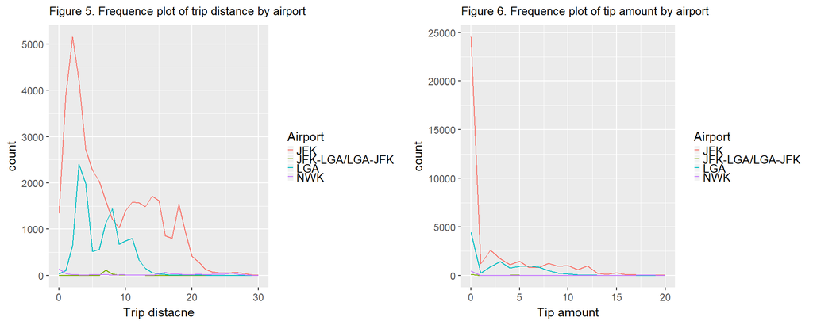

```r
#frequence plot of trip distance by airport trips
p1= ggplot(air_taxi[air_taxi$Airport!="Not airport",], aes(air_taxi$Trip_distance[air_taxi$Airport!="Not airport"], colour =air_taxi$Airport[air_taxi$Airport!="Not airport"])) + geom_freqpoly(binwidth = 1)     +theme(legend.text=element_text(size=10),legend.key.size = unit(0.2, "cm"),plot.title = element_text(size=10)) + xlim(c(0,30)) + ggtitle("Figure 5. Frequence plot of trip distance by airport") + scale_color_discrete(name="Airport") + labs(x="Trip distacne")
#frequence plot of tip amount by airport trips
p2= ggplot(air_taxi[air_taxi$Airport!="Not airport",], aes(air_taxi$Tip_amount[air_taxi$Airport!="Not airport"], colour =air_taxi$Airport[air_taxi$Airport!="Not airport"] )) +theme(legend.text=element_text(size=10),legend.key.size = unit(0.2, "cm"),plot.title = element_text(size=10)) +
  geom_freqpoly(binwidth = 1) + xlim(c(0,20)) + ggtitle("Figure 6. Frequence plot of tip amount by airport")+scale_color_discrete(name="Airport") +labs(x="Tip amount")

multiplot(p1, p2, cols=2)
```

Figure 5 shows that most of the airport trips are from/to JFK and LGA. Distribution of trips from/to JFK has two peaks, one is around 2.5 miles, has smaller spread, the other is around 15 miles with a larger spread. It also shows that distance from/to LGA tends to be smaller than JFk, since LGA is closer to New york City center.

Figure 6 shows that tips for most of the trips is less than 5 dollars.Distribution of tip amount for each airport has similar shape.

### Question 4

> - *Build a derived variable for tip as a percentage of the total fare.*

Before we proceed with this, some cleaning is necessary. Since the initial charge for NYC green taxi is $2.5, any transaction with a smaller total amount is invalid, thus they are to be dropped.

```r
#calculate the tip percentage
tip<- air_taxi[air_taxi$Total_amount>=2.5,]
tip$tip_per <- tip$Tip_amount/tip$Total_amount*100
summary(tip$tip_per)
```

```
##    Min. 1st Qu.  Median    Mean 3rd Qu.    Max.
##   0.000   0.000   0.000   6.662  16.667  99.020
```

From the summary, meadian is 0, half of the taxi trips have no tips. Distribution for tip percentage is extreme right skewed, which will cause problem in regression.

> - *Build a predictive model for tip as a percentage of the total fare.*

#### **feature engineering & cleaning**

**Data Clean:**

There are outliers in several numerical varibles. For example, some trips have 80% tip percentage, some trips’ average speed are higher than 100 miles per hour. Though they may happen, they are highly influential when building the model, so the best choice is deleting them.

**Feature engineering(more detailed in variable table in appendix):**

- **Time variables: Week, Day of month,Day of week, hour of day, time period in each day and trip time.** The are created since t people may be willing to tip depending on the week days or time of the day. For instance, people are more friendly and less stressful to easily tip over the weekend. They are derived from pickup time.
- **Speed: The ratio of trip distance to trip time.**
- **Direction_NS (is the cab moving Northt to South?) and Direction_EW (is the cab moving East to West).** These are components of the two main directions, horizontal and vertical. They are derived from pickup and dropoff locations.

```r
#calculate the distcnce form the center of New York City
NYC_loc <- c(-74.0059, 40.7128)
tip$pick_dist <-  sqrt((tip$Pickup_longitude - NYC_loc[1])^2 + (tip$Pickup_latitude - NYC_loc[2])^2)
tip$drop_dist <-  sqrt((tip$Dropoff_longitude - NYC_loc[1])^2 + (tip$Dropoff_latitude - NYC_loc[2])^2)

#creat the a categorical varibale to show wether the trio to/from Manhattan
if(!require('sp')){install.packages('sp'); require('sp')}
manhattan_lat <- c(40.796937,40.787945,40.782772,40.794715,40.811261,40.835371,40.868910,40.872719,40.878252,40.850557,40.836225,40.806050)
manhattan_lon <- c(-73.949503,-73.955822,-73.943575,-73.929801,-73.934153,-73.934515,-73.911145,-73.910765,-73.926350,-73.947262,-73.949899,-73.971255)
Man_pick<-point.in.polygon(tip$Pickup_latitude,tip$Pickup_longitude,manhattan_lat,manhattan_lon)
tip$Man_pick[Man_pick==0] <- "not Manhattan"
tip$Man_pick[Man_pick!=0] <- "Manhattan"
Man_drop<-point.in.polygon(tip$Dropoff_latitude,tip$Dropoff_longitude,manhattan_lat,manhattan_lon)
tip$Man_drop[Man_drop==0] <- "not Manhattan"
tip$Man_drop[Man_drop!=0] <- "Manhattan"

#creat time variables
pick_time<- strptime(tip$lpep_pickup_datetime,"%Y-%m-%d %H:%M:%S")
tip$Month_day <-pick_time[[4]]
drop_time <- strptime(tip$Lpep_dropoff_datetime,"%Y-%m-%d %H:%M:%S")
tip$time_diff <- as.numeric(difftime(drop_time,pick_time,units="mins"))
names(tip)[names(tip) == 'Day_hour'] <- 'Pick_hour'
tip$Drop_hour <- strptime(tip$Lpep_dropoff_datetime,"%Y-%m-%d %H:%M:%S")[[3]]
tip$period <- 1
tip$period[tip$Drop_hour>=7 & tip$Drop_hour<15] <- 2
tip$period[tip$Drop_hour>=15 & tip$Drop_hour<23] <- 3

#creat direction variables
tip$Direction_NS <- 0
tip$Direction_NS <- tip$Direction_NS - (tip$Pickup_latitude<tip$Dropoff_latitude)*1
tip$Direction_NS <- tip$Direction_NS + (tip$Pickup_latitude>tip$Dropoff_latitude)*1
tip$Direction_EW <- 0
tip$Direction_EW <- tip$Direction_EW - (tip$Pickup_longitude<tip$Dropoff_longitude)*1
tip$Direction_EW <- tip$Direction_EW + (tip$Pickup_longitude>tip$Dropoff_longitude)*1

#Creat speed variable per min
tip$speed <- tip$Trip_distance/(tip$time_diff/60)

#creat tip_YN to identify whether the trip has tip or not
tip$tip_YN<- 'No tips'
tip$tip_YN[tip$tip_per>0] <- "Tips"

#cleaning
tip <- tip[tip$tip_per<75,]
tip <- tip[tip$Tolls_amount <20,]
tip <- tip[tip$Tolls_amount <20,]
tip <- tip[tip$speed <100,]

#make them categorical
var_f <- c("Month_day","period","Man_pick","Man_drop","Drop_hour","Direction_NS","Direction_EW","tip_YN")
tip[,var_f] <- lapply(tip[,var_f],as.factor)
```

#### **Visualizaion**

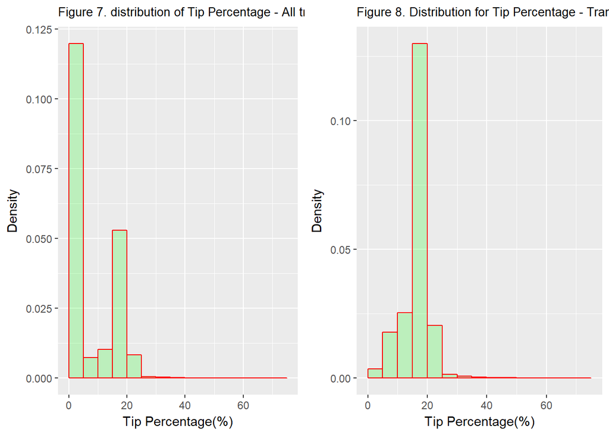

```r
p1 = ggplot(data=tip, aes(tip$tip_per)) +
     geom_histogram(breaks=seq(0, 75, by = 5), aes(y=..density..),col="red", fill="green", alpha = .2) +
     labs(title="Figure 7. distribution of Tip Percentage - All transaction ") +
     labs(x="Tip Percentage(%)", y="Density") + theme(plot.title = element_text(size=10))+
     xlim(c(0,75))
p2 = ggplot(data=tip[tip$tip_per>0,], aes(tip$tip_per[tip$tip_per>0])) +
     geom_histogram(breaks=seq(0, 75, by = 5), aes(y=..density..), col="red", fill="green", alpha = .2) +
     labs(title="Figure 8. Distribution for Tip Percentage - Transaction with tips") +
     labs(x="Tip Percentage(%)", y="Density") + theme(plot.title = element_text(size=10))+
     xlim(c(0,75))

multiplot(p1, p2, cols=2)
```

Compared with Figure 7 and Figure 8, most of passengers won’t givetips, if they give tips, tip percentage is between 10% to 25%.

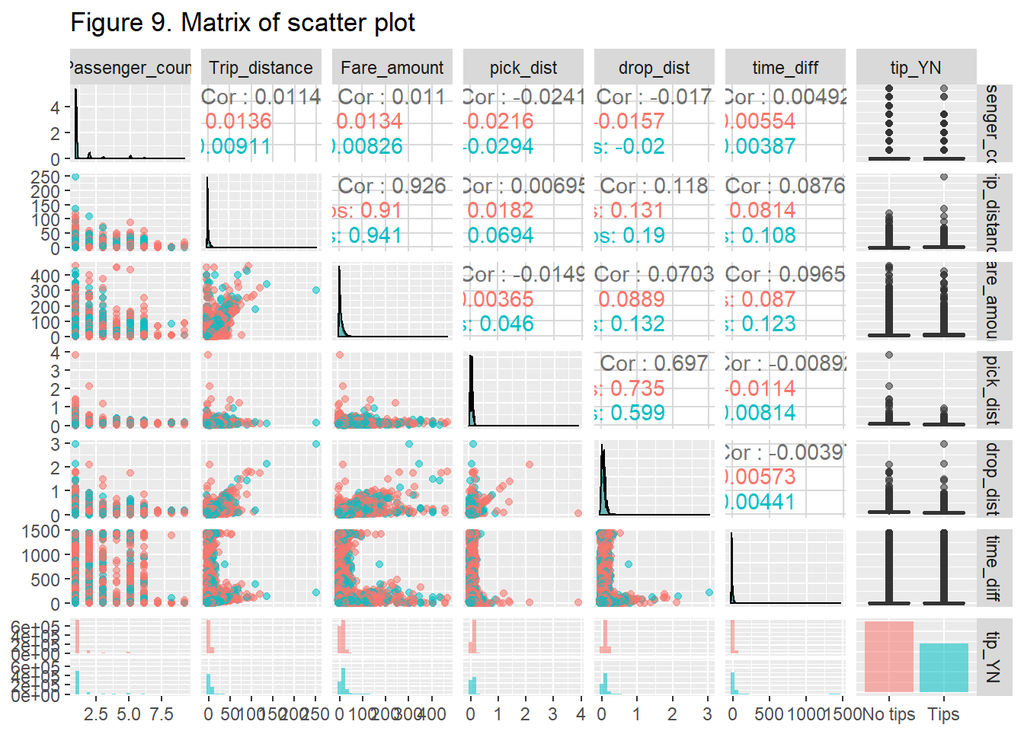

```r
if(!require('GGally')){install.packages('GGally'); require('GGally')}
ggpairs(tip[,c(10:12,27,28,32,38)], aes(colour = tip_YN, alpha = 0.1),title = "Figure 9. Matrix of scatter plot")
```

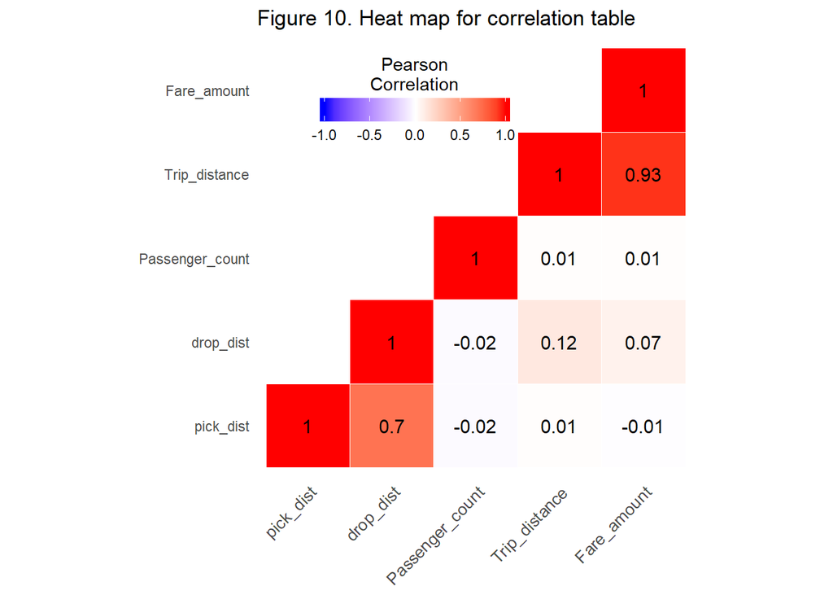

```r
mydata <- tip[, c(10:12,27,28)]
cormat <- round(cor(mydata),2)
library(reshape2)
melted_cormat <- melt(cormat)

# Get lower triangle of the correlation matrix
  get_lower_tri<-function(cormat){
    cormat[upper.tri(cormat)] <- NA
    return(cormat)
  }
  # Get upper triangle of the correlation matrix
  get_upper_tri <- function(cormat){
    cormat[lower.tri(cormat)]<- NA
    return(cormat)
  }

upper_tri <- get_upper_tri(cormat)


melted_cormat <- melt(upper_tri, na.rm = TRUE)

reorder_cormat <- function(cormat){
# Use correlation between variables as distance
dd <- as.dist((1-cormat)/2)
hc <- hclust(dd)
cormat <-cormat[hc$order, hc$order]
}
cormat <- reorder_cormat(cormat)
upper_tri <- get_upper_tri(cormat)
# Melt the correlation matrix
melted_cormat <- melt(upper_tri, na.rm = TRUE)
# Create a ggheatmap
ggheatmap <- ggplot(melted_cormat, aes(Var2, Var1, fill = value))+
 geom_tile(color = "white")+
   ggtitle("Figure 10. Heat map for correlation table") +
 scale_fill_gradient2(low = "blue", high = "red", mid = "white",
   midpoint = 0, limit = c(-1,1), space = "Lab",
    name="Pearson\nCorrelation") +
  theme_minimal()+ # minimal theme
 theme(axis.text.x = element_text(angle = 45, vjust = 1,
    size = 10, hjust = 1))+
 coord_fixed()
#set parameter in ggplot
ggheatmap +
geom_text(aes(Var2, Var1, label = value), color = "black", size = 4) +
theme(
  axis.title.x = element_blank(),
  axis.title.y = element_blank(),
  panel.grid.major = element_blank(),
  panel.border = element_blank(),
  panel.background = element_blank(),
  axis.ticks = element_blank(),
  legend.justification = c(1, 0),
  legend.position = c(0.6, 0.75),
  legend.direction = "horizontal")+
  guides(fill = guide_colorbar(barwidth = 8, barheight = 1,
                title.position = "top", title.hjust = 0.5))
```

#### **Choice of model**

The first method comes into mind is multiple linear regression. For this data set, around 50% of tip percentage is 0, so multiple linear regression won’t have good performance. Can we use some transformation on tip percentage? Standerlization and log transformation are considered, but after transformation, distribution of target variable is still not normal, not fit for linear regression.

Regression tree is a good choice. Since regression tree can partition the space, so it can slove the problem that distribution of tip percentage is right skewed.**Generalized Boosted Regression Modeling** is performed here.

#### **Gradient Boosting Machine for Tree**

##### Steps for modeling

###### 1. Spliting data into train (80%) and test(20%)

###### 2. Using 5 fold cross-validation tuning hyper parameter in train data set

The proposal is listed above. The problem is Green Taxi data is too large that the whole data can’t be used. To slove this, i try to use a subset of the data to build the model. I select 15000 random observations as the training data and 5000 random observations as test data.Tuning hyper parameter on the training data, finding the parameter for best performance, then fit the model on whole training data and perdict the tip percentage on test data set, calculating out the root-mean-square error.

```r
set.seed(818)
#variables put into model
var_list <- c("RateCodeID","Passenger_count","Trip_distance","Fare_amount","Payment_type","Pick_hour","Airport","pick_dist","drop_dist","Man_pick","Man_drop","time_diff","period","week_day","num_week","Direction_NS","Direction_EW","tip_per")
data_pre<- tip[,var_list]
#random sample from data, get train and test data set
index <- sample(1:1463516, 20000, replace=F)
data_train <- data_pre[index[1:15000],]
data_test <- data_pre[tail(index,5000),]
```

When Tuning parameter, grid search is used. For interaction depth, 1 to 4 are tried. For numbers of tree, 400,600,800 are treid. For shrikage parameter, 0.1,0.01,0.001 are tried.

```r
#require package
if(!require('gbm')){install.packages('gbm'); require('gbm')}
if(!require('plyr')){install.packages('plyr'); require('plyr')}
library(caret)
#set 5 fold cross validation
control <- trainControl(method="cv", number=5)
#set grid search
gbmGrid <- expand.grid(interaction.depth = 1:4,
                       shrinkage = c(0.1,0.01,0.001),
                       n.trees = c(400,600,800),
                       n.minobsinnode = 10)
#training
gbm_gridsearch <- train(tip_per~., data=data_train, method="gbm", tuneGrid=gbmGrid,metric='RMSE', trControl=control)
```

```r
#print result
print(gbm_gridsearch)
```

```
## Stochastic Gradient Boosting
##
## 15000 samples
##    17 predictor
##
## No pre-processing
## Resampling: Cross-Validated (5 fold)
## Summary of sample sizes: 12000, 12000, 12000, 12000, 12000
## Resampling results across tuning parameters:
##
##   shrinkage  interaction.depth  n.trees  RMSE      Rsquared
##   0.001      1                  400      6.905807  0.6520512
##   0.001      1                  600      6.364274  0.6520512
##   0.001      1                  800      5.973444  0.6520512
##   0.001      2                  400      6.879991  0.6625030
##   0.001      2                  600      6.326300  0.6631203
##   0.001      2                  800      5.924394  0.6638036
##   0.001      3                  400      6.872416  0.6650421
##   0.001      3                  600      6.314283  0.6661112
##   0.001      3                  800      5.908291  0.6670763
##   0.001      4                  400      6.867734  0.6664630
##   0.001      4                  600      6.307078  0.6678249
##   0.001      4                  800      5.898812  0.6689483
##   0.010      1                  400      5.048990  0.6597804
##   0.010      1                  600      5.009197  0.6638496
##   0.010      1                  800      4.994425  0.6654028
##   0.010      2                  400      4.954146  0.6709582
##   0.010      2                  600      4.938875  0.6724961
##   0.010      2                  800      4.934067  0.6730541
##   0.010      3                  400      4.936382  0.6730534
##   0.010      3                  600      4.928915  0.6737514
##   0.010      3                  800      4.928170  0.6737739
##   0.010      4                  400      4.928861  0.6740107
##   0.010      4                  600      4.923542  0.6744108
##   0.010      4                  800      4.922893  0.6744306
##   0.100      1                  400      4.984484  0.6662170
##   0.100      1                  600      4.987746  0.6657535
##   0.100      1                  800      4.990885  0.6653083
##   0.100      2                  400      4.948037  0.6711116
##   0.100      2                  600      4.959872  0.6694872
##   0.100      2                  800      4.969102  0.6682832
##   0.100      3                  400      4.962273  0.6692092
##   0.100      3                  600      4.975053  0.6675168
##   0.100      3                  800      4.998286  0.6645389
##   0.100      4                  400      4.976368  0.6673273
##   0.100      4                  600      5.002821  0.6639805
##   0.100      4                  800      5.023771  0.6612352
##
## Tuning parameter 'n.minobsinnode' was held constant at a value of 10
## RMSE was used to select the optimal model using  the smallest value.
## The final values used for the model were n.trees = 800,
##  interaction.depth = 4, shrinkage = 0.01 and n.minobsinnode = 10.
```

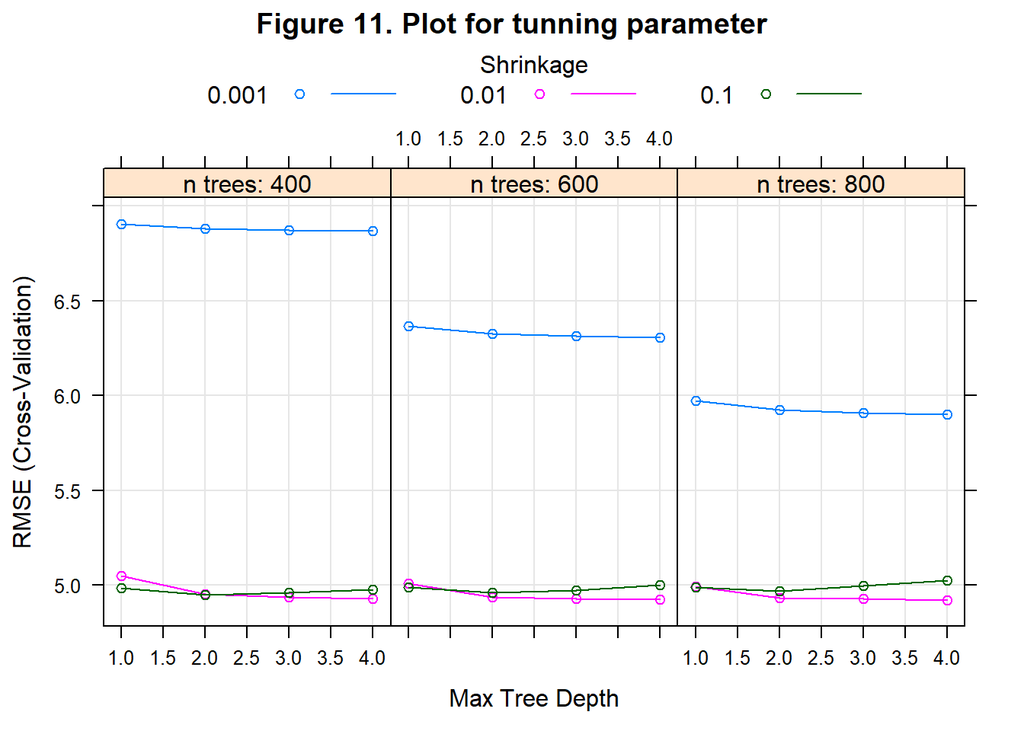

```r
plot(gbm_gridsearch,main="Figure 11. Plot for tunning parameter")
```

Seeing from Figure 11, when interaction depth is 4, number of tree is 800, shrinkage is 0.01, we have lowest rooted-mean-square error. So we use this seeting, getting our model from the whole training data.

```r
fit.gbm <- gbm(tip_per ~ ., data=data_train, n.tree = 800,shrinkage = 0.01, interaction.depth = 4,n.minobsinnode = 10)
```

```
## Distribution not specified, assuming gaussian ...
```

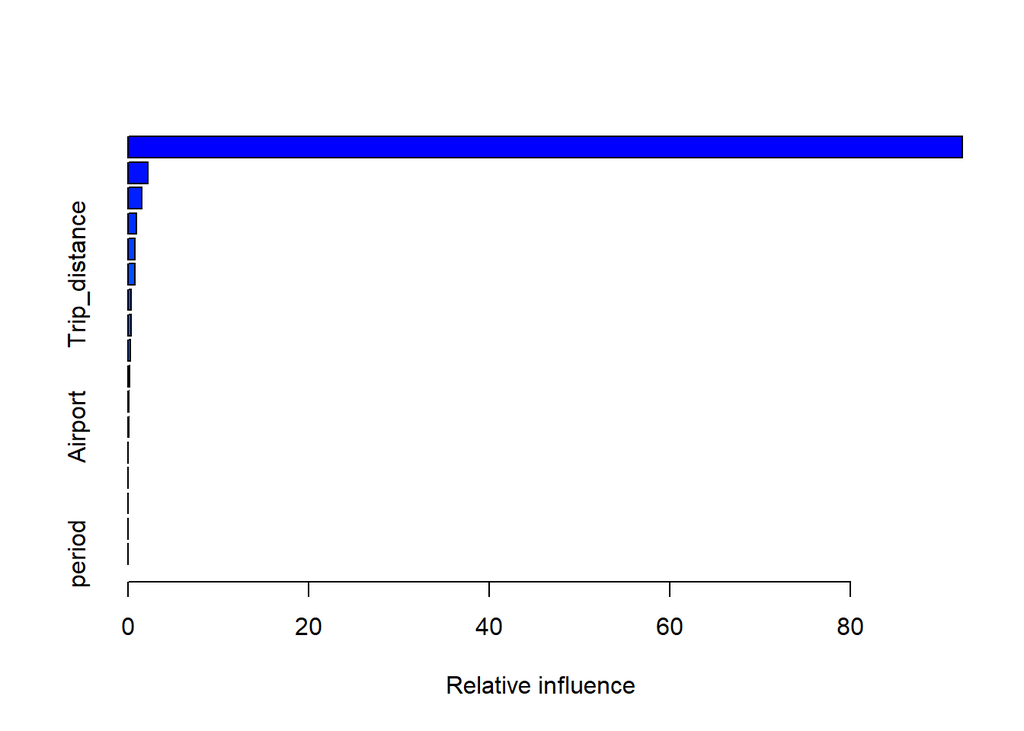

```
##                             var      rel.inf
## Payment_type       Payment_type 92.422657295
## Pick_hour             Pick_hour  2.213049844
## pick_dist             pick_dist  1.519316831
## drop_dist             drop_dist  0.958792247
## time_diff             time_diff  0.773713151
## Trip_distance     Trip_distance  0.749673634
## Fare_amount         Fare_amount  0.366723339
## RateCodeID           RateCodeID  0.318298905
## Man_drop               Man_drop  0.262107133
## week_day               week_day  0.196777223
## Man_pick               Man_pick  0.065986301
## Airport                 Airport  0.065623983
## num_week               num_week  0.036042427
## Direction_NS       Direction_NS  0.027107557
## Passenger_count Passenger_count  0.012775031
## Direction_EW       Direction_EW  0.009719627
## period                   period  0.001635473
```

```r
summary(fit.gbm)
```

Seeing from variable importance, **Payment_type** has highest relative importance, this make sense since ttip only recorded when using credit card. Pick_hour, pick_distance, drop_distance, time_diff(trip time) are also quite important.

After we store the model in **fit.gbm**, we predict the tip percentage on 5000 observations in test data set, calculating the RMSE.

```r
preds <- predict(fit.gbm, newdata = data_test, n.trees = 800,shrinkage=0.01,interaction.depth = 4,n.minobsinnode = 10)
(sum((preds-data_test$tip_per)^2)/5000)^0.5
```

```
## [1] 4.970972
```

We have similar performance compared with tuning part, root-mean-square error is around 5.

### Question 5 option A

> - *Build a derived variable representing the average speed over the course of a trip.*

```r
#delete rows which mph<=1
speed_taxi <- tip[tip$speed > 1,]
summary(speed_taxi$speed)
```

```
##    Min. 1st Qu.  Median    Mean 3rd Qu.    Max.
##   1.001   9.474  11.860  13.089  15.132  99.771
```

From the summary, distribution of speed is also right skewed.

> - *Can you perform a test to determine if the average trip speeds are materially the same in all weeks of September? If you decide they are not the same, can you form a hypothesis regarding why they differ?*

##### **ANOVA:**

```r
speed_test <- aov(speed ~ week_day, data = speed_taxi)
summary(speed_test)
```

```
##                  Df   Sum Sq Mean Sq F value Pr(>F)
## week_day          6   564177   94030    2846 <2e-16 ***
## Residuals   1453940 48028798      33
## ---
## Signif. codes:  0 '***' 0.001 '**' 0.01 '*' 0.05 '.' 0.1 ' ' 1
```

ANOVA test shows **statistical significant** result, but we should be careful here. Significant differences (reject the null hypothesis) means that differences in group means are not likely due to sampling error.The problem is that statistically significant differences can be found even with very small differences if the sample size is large enough. In fact, differences between any sample means will be significant if the sample is large enough. So a better choice is focuing on **practical significance**.

> - *Can you build up a hypothesis of average trip speed as a function of time of day?*

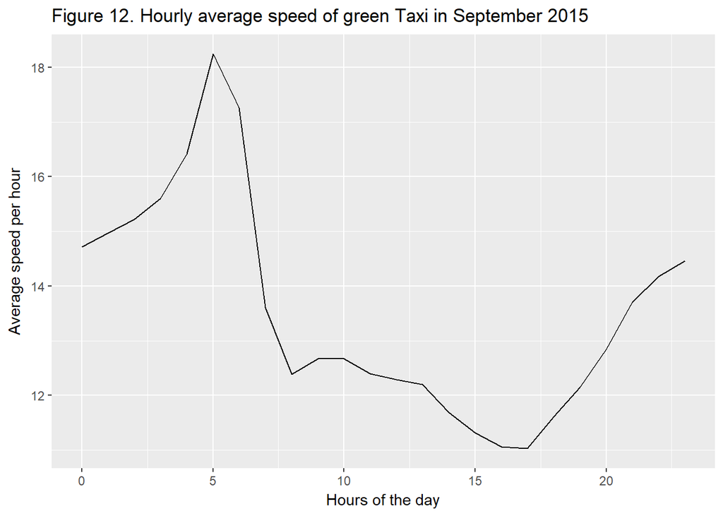

```r
hour_mean_speed <- tapply(tip$speed, tip$Pick_hour, mean)
hour_mean_speed <- as.data.frame(hour_mean_speed)
colnames(hour_mean_speed)[1] <- "AverageSpeed"
ggplot(hour_mean_speed, aes(x=c(0:23))) + geom_line(aes(y=AverageSpeed)) + ggtitle("Figure 12. Hourly average speed of green Taxi in September 2015") + labs(x= "Hours of the day", y="Average speed per hour")
```

## Further discussion

### Part to improve

#### Reading data

data.table and curl are used to load the data into R, it’s better than read.csv, but there are more advanced packages can improve the efficiency when reading the data.

#### Modeling

- I should make total use of data, for example, latitude and longitude in data. **revgeocode** can be used to get location information. The limited usage for revgeocode is 25000 per day, so i don’t use it at this time.
- When using ensemble method for regression tree, the computer dosen’t have enough memory to allocate the vector. we’d better find other method to model on the whole data set or find parallel computing method with ensemble method.
- I should try different algorithms to fit the data,and compare the performance, such as random forest. I can also try different loss functions or optimizations in grediant boosted machine.
- Find some way to improve efficiency when fitting the model.

## Appendix

### **Data dictionary fOr GBM**

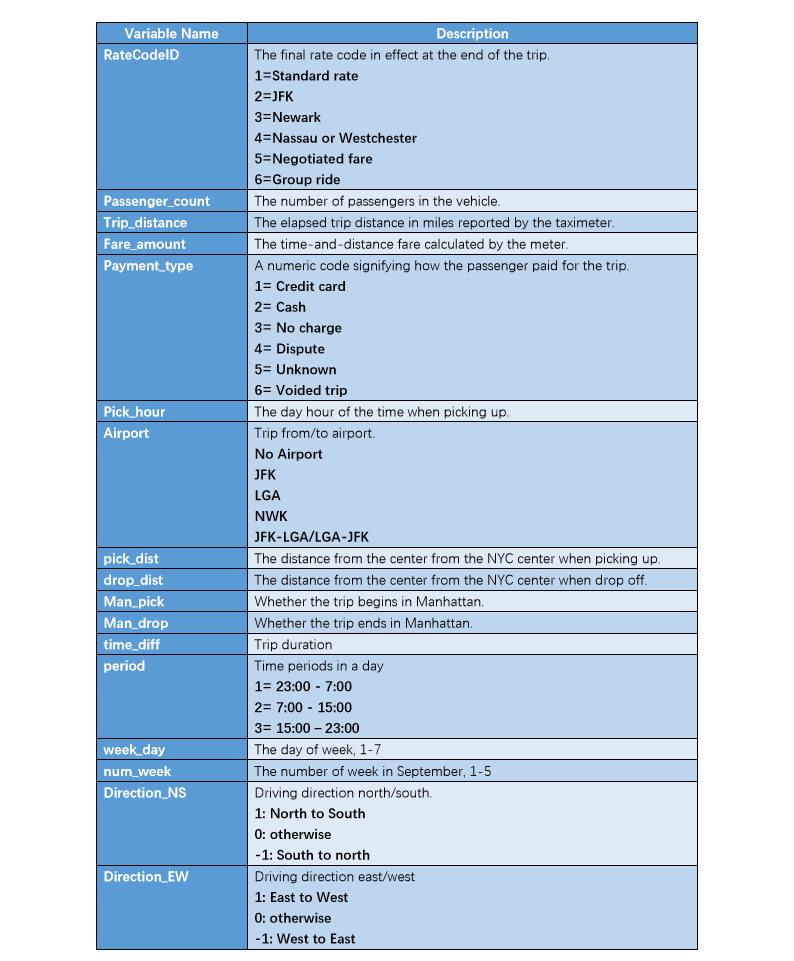

## Reference

caret package: http://topepo.github.io/caret/using-your-own-model-in-train.html

point.in.polygon function: https://www.rdocumentation.org/packages/sp/versions/1.2-5/topics/point.in.polygon

data dictionary: http://www.nyc.gov/html/tlc/downloads/pdf/data_dictionary_trip_records_green.pdf

ARIMA model: https://en.wikipedia.org/wiki/Autoregressive_integrated_moving_average